# Homework 4

< Jake Hiltscher >

*Note that you do not need to properly format the axis limits in your plots for this assignment (to save time). You should, however, still make the plots square in shape.*

## Data and Description

Measuring body fat is not simple. One method requires submerging the body underwater in a tank and measuring the increase in water level. A simpler method for estimating body fat would be preferred. In order to develop such a method, researchers recorded age (years), weight (pounds), height (inches), and three body circumference measurements (around the neck, chest, and abdominal (all in centimeters)) for 252 men. Each man’s percentage of body fat was accurately estimated by an underwater weighing technique (the variable brozek is the percentage of body fat). The hope is to be able to use this data to create a model that will accurately predict body fat percentage, by using just the basic variables recorded, without having to use the tank submerging method.

The data can be found in the BodyFat data set on Canvas. Download “BodyFat.txt”, and put it in the same folder as this R Markdown file.

#### 0. Replace the text “< PUT YOUR NAME HERE >” (above next to “author:”) with your full name.

#### 1. Read in the data set, and call the data frame “bodyfat”. Print a summary of the data and make sure the data makes sense. **Remove the “row” column (which contains row numbers) from the data set.**

```r
bodyfat <- read_table("BodyFat.txt") %>% select(-c('row'))
head(bodyfat)
```

```
## # A tibble: 6 × 7
##   brozek   age weight height  neck chest abdom
##    <dbl> <dbl>  <dbl>  <dbl> <dbl> <dbl> <dbl>
## 1   12.6    23   154.   67.8  36.2  93.1  85.2
## 2    6.9    22   173.   72.2  38.5  93.6  83
## 3   24.6    22   154    66.2  34    95.8  87.9
## 4   10.9    26   185.   72.2  37.4 102.   86.4
## 5   27.8    24   184.   71.2  34.4  97.3 100
## 6   20.6    24   210.   74.8  39   104.   94.4
```

#### 2. Create and print a scatterplot matrix of the data.

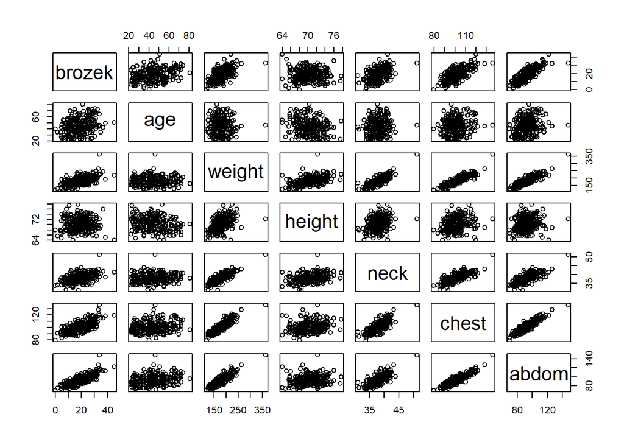

```r
# your code here
pairs(bodyfat)
```

#### 3. Based on the scatterplot matrix, briefly explain which variables you think will be “significant” for predicting brozek and which variables you think will *not* be helpful at predicting brozek. Explain how the scatterplot helped determine your answers.

There are two variables that I think be significant, abdom and chest. The scatter plot shows a pretty strong linear regression between the two with brozek.

#### 4. Create and print a correlation matrix (numeric or color- and shape-coded).

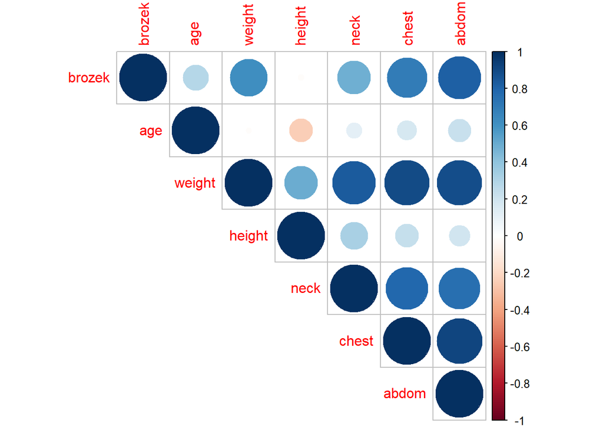

```r
corrplot(cor(bodyfat), type = "upper")
```

#### 5. Based on the scatterplot matrix and the correlation matrix, are their any pairs of variables that you suspect will cause a problem for the multicollinearity assumption? If so, which ones?

I think there’s an issue of multicollinearity between weight and abdom, and chest and abdom.

#### 6. Fit a multiple linear regression model to the data (no transformations). Print a summary of the results. Save the residuals to the `bodyfat` data frame.

```r
bodyfat_lm <- lm(brozek ~ ., data = bodyfat)

summary(bodyfat_lm)
```

```
##
## Call:
## lm(formula = brozek ~ ., data = bodyfat)
##
## Residuals:
##      Min       1Q   Median       3Q      Max
## -11.5811  -3.0358   0.0668   2.8879  10.2828
##
## Coefficients:
##               Estimate Std. Error t value Pr(>|t|)
## (Intercept) -2.010e+01  1.413e+01  -1.423   0.1561
## age          5.010e-03  2.540e-02   0.197   0.8438
## weight      -8.733e-02  3.879e-02  -2.251   0.0253 *
## height      -1.400e-01  1.520e-01  -0.921   0.3579
## neck        -4.421e-01  2.019e-01  -2.189   0.0295 *
## chest        4.844e-04  9.107e-02   0.005   0.9958
## abdom        8.754e-01  7.924e-02  11.048   <2e-16 ***
## ---
## Signif. codes:  0 '***' 0.001 '**' 0.01 '*' 0.05 '.' 0.1 ' ' 1
##
## Residual standard error: 4.124 on 244 degrees of freedom
## Multiple R-squared:  0.722,  Adjusted R-squared:  0.7151
## F-statistic: 105.6 on 6 and 244 DF,  p-value: < 2.2e-16
```

```r
bodyfat$residuals <- bodyfat_lm$residuals
bodyfat$fittedbrozek <- bodyfat_lm$fitted.values
```

#### 7. Briefly comment on the “significance” of the variables: were you surprised by the results? Are there any variables that are significant that you think shouldn’t be? Are there any variables that are not significant that you think should be?

I’m not really surprised with any of the significant variables. Although, I’m surprised that chest isn’t a significant factor. I also expected weight to have a really small p-value.

#### 8. Briefly comment on the sign (+/-) of the coefficients for the variables. Are their any variables where the sign is the opposite of what you expected?

I expected that weight would have a negative coefficient.

#### 9. Mathematically write out the *fitted* multiple linear regression model for this data set using the coefficients you found above (do not use betas). Do not use “X” and “Y” in your model - use variable names that are fairly descriptive.

$\text{brozek}_i)$ $=$ $-20.10089$ $+$ $0.00501*$$\text{Age}_i$ $-$ $0.08733*$$\text{Weight}_i$ $-$ $0.14001*$$\text{Height}_i$ $-$ $+0.4421*$$\text{Neck}_i$ $+$ $0.00048*$$\text{Chest}_i$ $+$ $0.87541*$$\text{Abdom}_i$

#### 10. *Assuming* the model assumptions are all met, how would you interpret the coefficient for Weight?

Holding all else constant, as weight increases by one pound, average brozek decreases by 0.08733.

#### 11. Briefly explain what it means to “hold all else constant” when interpreting a coefficient.

Average of Y every one unit increase of coefficient of some variable, holding all other variables constant at any value. Holding constant means to hold other variable values the same, then Y will increase or decrease at an exact rate as X increases by one unit.

#### 12. Briefly explain what the F-test indicates, as reported in the model output from question 6.

The F-test statistic of 105.6 is high, meaning the model is significant and better than a model with no independent variables.

#### 13. Briefly interpret the *adjusted* R-squared, as reported in the model output from question 6.

The adj $R^2$ value is 0.7151. This suggests that the model is leaning towards being a good fit but it could be better.

### Questions 14-20 involve using diagnostics to determine if the linear regression assumptions are met. For each assumption, (1) perform appropriate diagnostics to determine if the assumption is violated, and (2) explain whether or not you think the assumption is violated and why you think that.

#### 14. (L) The X’s vs Y are linear (use the residual vs. predictor plots, partial regression plots, and one other diagnostic tool of your choice).

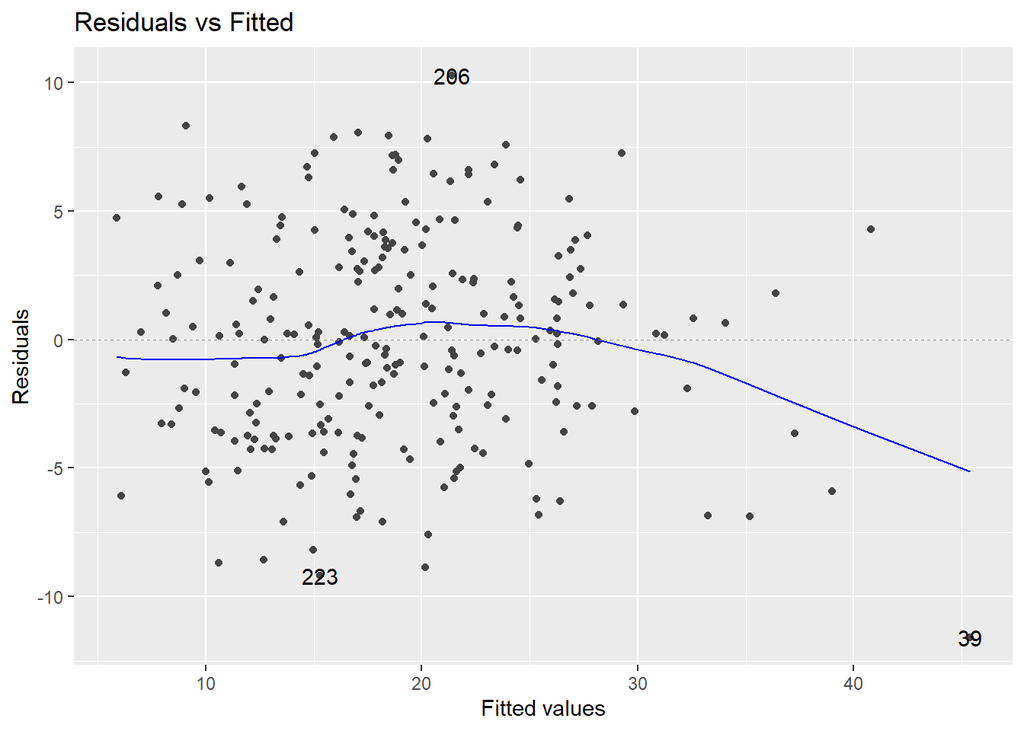

```r
# residual vs. predictor plots
(bodyfat_resid_fitted_plot <- autoplot(bodyfat_lm, which = 1, ncol = 1, nrow = 1))
```

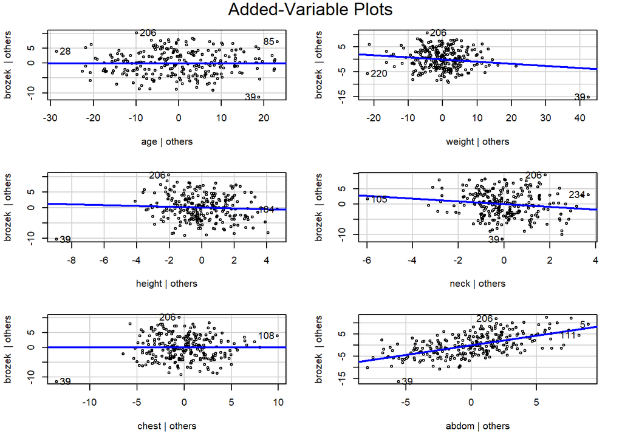

```r
# partial regression plots
avPlots(bodyfat_lm)
```

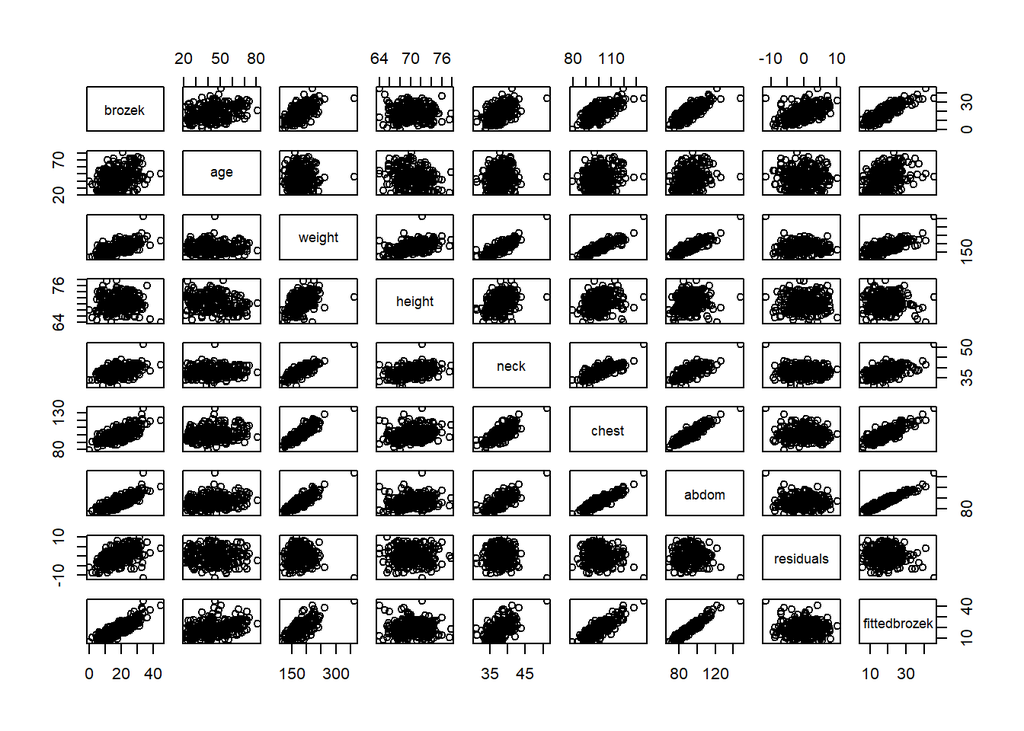

```r
# one other plot of your choice
pairs(bodyfat)
```

This assumption is met based on the three graphics above. No pattern is evident in any of these.

#### 15. (I) The residuals are independent (no diagnostic tools - just think about how the data was collected and briefly write your thoughts)

The residuals are independent in the model, they are not recorded over time.

#### 16. (N) The residuals are normally distributed and centered at zero (use all four diagnostic tools)

```r
# Diagnostic 1
shapiro.test(bodyfat$brozek)
```

```
##
##  Shapiro-Wilk normality test
##
## data:  bodyfat$brozek
## W = 0.99308, p-value = 0.2956
```

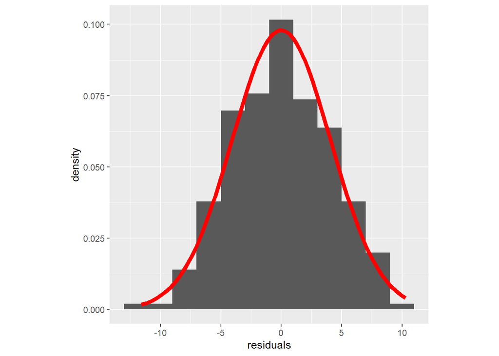

```r
# Diagnostic 2
bodyfat_hist <- ggplot(data = bodyfat) +
  # when using this code for future data sets, make sure to change the binwidth
  geom_histogram(mapping = aes(x = residuals, y = ..density..),
                 binwidth = 2) +
  # stat_function() overlays the red normal curve on the histogram
  stat_function(fun = dnorm,
                color = "red",
                size = 2,
                args = list(mean = mean(bodyfat$residuals),
                            sd = sd(bodyfat$residuals))) +
  theme(aspect.ratio = 1)
bodyfat_hist
```

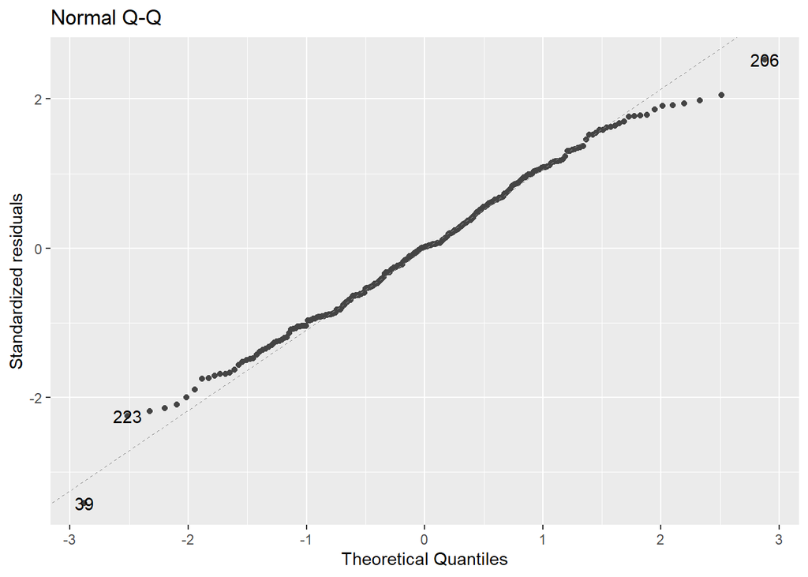

```r
# Diagnostic 3
autoplot(bodyfat_lm, which = 2, ncol = 1, nrow = 1)
```

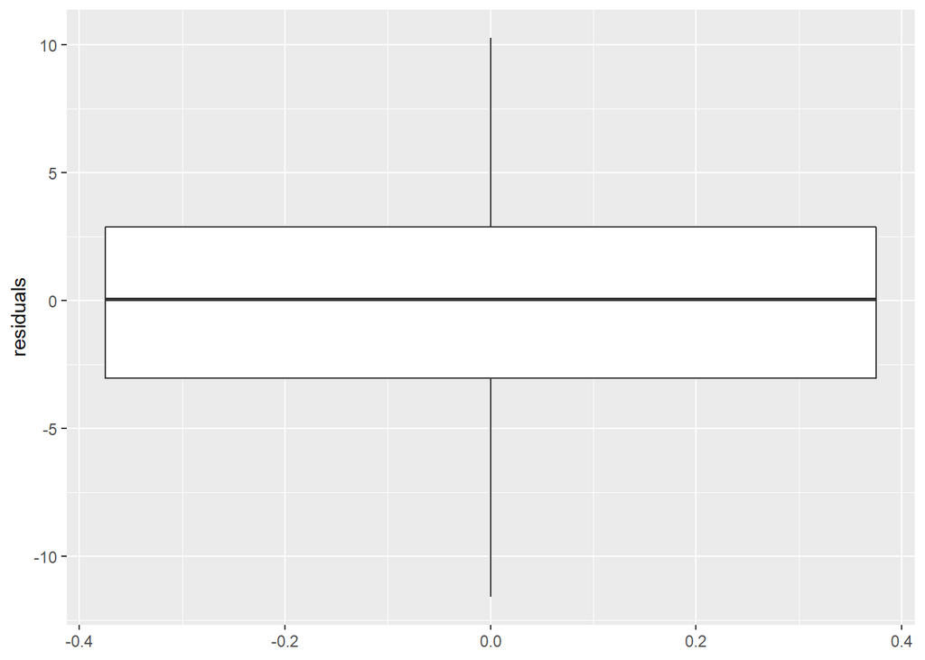

```r
# Diagnostic 4
ggplot(data = bodyfat, mapping = aes(y = residuals)) +
  geom_boxplot()
```

This assumption is met. The residuals are all normally distributed around 0. The histogram is pretty clear in this.

#### 17. (E) The residuals have equal/constant variance across all values of X (only one diagnostic tool)

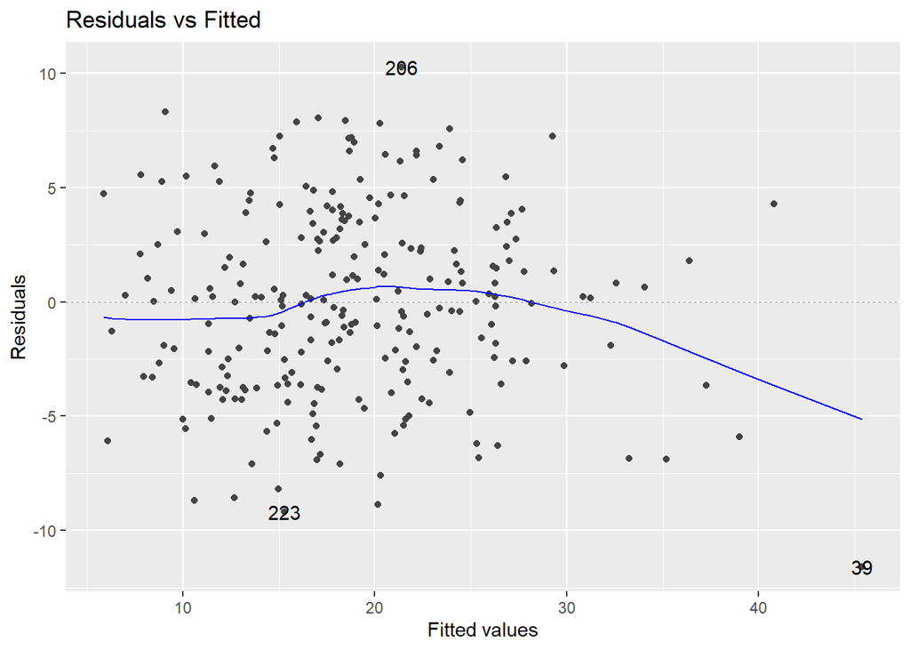

```r
# your code here
bodyfat_resid_fitted_plot
```

The model’s residuals have equal variance. There’s observation 39 that is an strong influential point that pulls on the right side. But I would say that it is met.

#### 18. (A) The model describes all observations (i.e., there are no influential points) (use Cook’s distance, DFBETAS, and DFFITS. Also, in your response, refer to the evidence from the plots you created in previous questions)

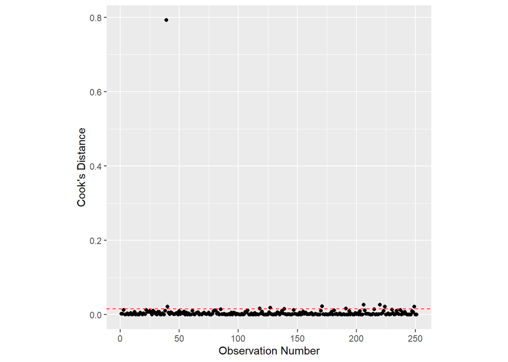

```r
# Cook's Distance
bodyfat$cooksd <- cooks.distance(bodyfat_lm)

# plot Cook's distance against the observation number
ggplot(data = bodyfat) +
  geom_point(mapping = aes(x = as.numeric(rownames(bodyfat)),
                           y = cooksd)) +
  ylab("Cook's Distance") +
  xlab("Observation Number") +
  geom_hline(mapping = aes(yintercept = 4 / length(cooksd)),
             color = "red",
             linetype = "dashed") +
  theme(aspect.ratio = 1)
```

```r
# print a list of potential outliers according to Cook's distance
bodyfat %>%
  mutate(rowNum = row.names(bodyfat)) %>%  # save original row numbers
  filter(cooksd > 4 / length(cooksd)) %>%  # select potential outliers
  arrange(desc(cooksd))  # order from largest Cook's distance to smallest
```

```
## # A tibble: 10 × 11
##    brozek   age weight height  neck chest abdom residuals fittedbrozek cooksd
##     <dbl> <dbl>  <dbl>  <dbl> <dbl> <dbl> <dbl>     <dbl>        <dbl>  <dbl>
##  1   33.8    46   363.   72.2  51.2 136.  148.     -11.6         45.4  0.793
##  2   12.7    54   153.   70.5  38.5  99    91.8     -7.61        20.3  0.0272
##  3   31.7    44   166    65.5  39.1 101.   93.9     10.3         21.4  0.0268
##  4    1.9    35   126.   65.5  34    90.8  75       -8.69        10.6  0.0222
##  5   28.3    72   187.   66    38.9 111.  112.      -6.88        35.2  0.0218
##  6   11.3    55   180.   68.8  41.1 107.   95.3     -8.86        20.2  0.0218
##  7   33.1    45   263.   68.8  43.2 128.  126.      -5.89        39.0  0.0212
##  8   17.4    43   152.   67.8  37.5  95.9  78        8.32         9.08 0.0191
##  9   25.1    40   191    74    38.3  95.4  92.4      8.04        17.1  0.0164
## 10   36.5    42   244.   76    41.8 115.  114.       7.25        29.3  0.0162
## # … with 1 more variable: rowNum <chr>
```

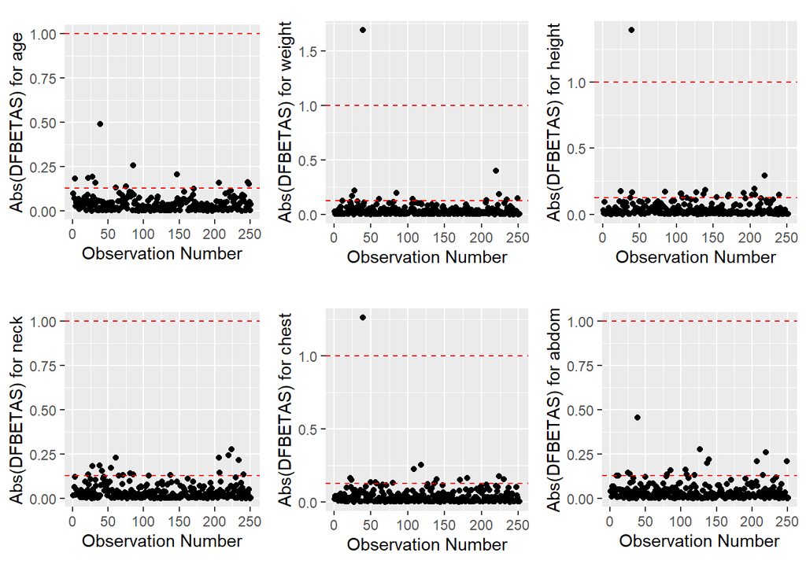

```r
# DFBETAS
# Age
bodyfat$dfbetas_age <- as.vector(dfbetas(bodyfat_lm)[, "age"])
# plot the DFBETAS against the observation number
dfbetas_plot_age <- ggplot(data = bodyfat) +
  geom_point(mapping = aes(x = as.numeric(rownames(bodyfat)),
                           y = abs(dfbetas_age))) +
  ylab("Abs(DFBETAS) for age") +
  xlab("Observation Number") +
  # for n > 30
  geom_hline(mapping = aes(yintercept = 2 / sqrt(length(dfbetas_age))),
             color = "red",
             linetype = "dashed") +
  # for n <= 30
  geom_hline(mapping = aes(yintercept = 1),
             color = "red",
             linetype = "dashed") +
  theme(aspect.ratio = 1)

# Weight
bodyfat$dfbetas_weight <- as.vector(dfbetas(bodyfat_lm)[, "weight"])
# plot the DFBETAS against the observation number
dfbetas_plot_weight <- ggplot(data = bodyfat) +
  geom_point(mapping = aes(x = as.numeric(rownames(bodyfat)),
                           y = abs(dfbetas_weight))) +
  ylab("Abs(DFBETAS) for weight") +
  xlab("Observation Number") +
  # for n > 30
  geom_hline(mapping = aes(yintercept = 2 / sqrt(length(dfbetas_weight))),
             color = "red",
             linetype = "dashed") +
  # for n <= 30
  geom_hline(mapping = aes(yintercept = 1),
             color = "red",
             linetype = "dashed") +
  theme(aspect.ratio = 1)

# Height
bodyfat$dfbetas_height <- as.vector(dfbetas(bodyfat_lm)[, "height"])
# plot the DFBETAS against the observation number
dfbetas_plot_height <- ggplot(data = bodyfat) +
  geom_point(mapping = aes(x = as.numeric(rownames(bodyfat)),
                           y = abs(dfbetas_height))) +
  ylab("Abs(DFBETAS) for height") +
  xlab("Observation Number") +
  # for n > 30
  geom_hline(mapping = aes(yintercept = 2 / sqrt(length(dfbetas_height))),
             color = "red",
             linetype = "dashed") +
  # for n <= 30
  geom_hline(mapping = aes(yintercept = 1),
             color = "red",
             linetype = "dashed") +
  theme(aspect.ratio = 1)

# Neck
bodyfat$dfbetas_neck <- as.vector(dfbetas(bodyfat_lm)[, "neck"])
# plot the DFBETAS against the observation number
dfbetas_plot_neck <- ggplot(data = bodyfat) +
  geom_point(mapping = aes(x = as.numeric(rownames(bodyfat)),
                           y = abs(dfbetas_neck))) +
  ylab("Abs(DFBETAS) for neck") +
  xlab("Observation Number") +
  # for n > 30
  geom_hline(mapping = aes(yintercept = 2 / sqrt(length(dfbetas_neck))),
             color = "red",
             linetype = "dashed") +
  # for n <= 30
  geom_hline(mapping = aes(yintercept = 1),
             color = "red",
             linetype = "dashed") +
  theme(aspect.ratio = 1)

# Chest
bodyfat$dfbetas_chest <- as.vector(dfbetas(bodyfat_lm)[, "chest"])
# plot the DFBETAS against the observation number
dfbetas_plot_chest <- ggplot(data = bodyfat) +
  geom_point(mapping = aes(x = as.numeric(rownames(bodyfat)),
                           y = abs(dfbetas_chest))) +
  ylab("Abs(DFBETAS) for chest") +
  xlab("Observation Number") +
  # for n > 30
  geom_hline(mapping = aes(yintercept = 2 / sqrt(length(dfbetas_chest))),
             color = "red",
             linetype = "dashed") +
  # for n <= 30
  geom_hline(mapping = aes(yintercept = 1),
             color = "red",
             linetype = "dashed") +
  theme(aspect.ratio = 1)

# Abdom
bodyfat$dfbetas_abdom <- as.vector(dfbetas(bodyfat_lm)[, "abdom"])
# plot the DFBETAS against the observation number
dfbetas_plot_abdom <- ggplot(data = bodyfat) +
  geom_point(mapping = aes(x = as.numeric(rownames(bodyfat)),
                           y = abs(dfbetas_abdom))) +
  ylab("Abs(DFBETAS) for abdom") +
  xlab("Observation Number") +
  # for n > 30
  geom_hline(mapping = aes(yintercept = 2 / sqrt(length(dfbetas_abdom))),
             color = "red",
             linetype = "dashed") +
  # for n <= 30
  geom_hline(mapping = aes(yintercept = 1),
             color = "red",
             linetype = "dashed") +
  theme(aspect.ratio = 1)

#Plot all DFBETAS
grid.arrange(dfbetas_plot_age,
             dfbetas_plot_weight,
             dfbetas_plot_height,
             dfbetas_plot_neck,
             dfbetas_plot_chest,
             dfbetas_plot_abdom,
             nrow = 2)
```

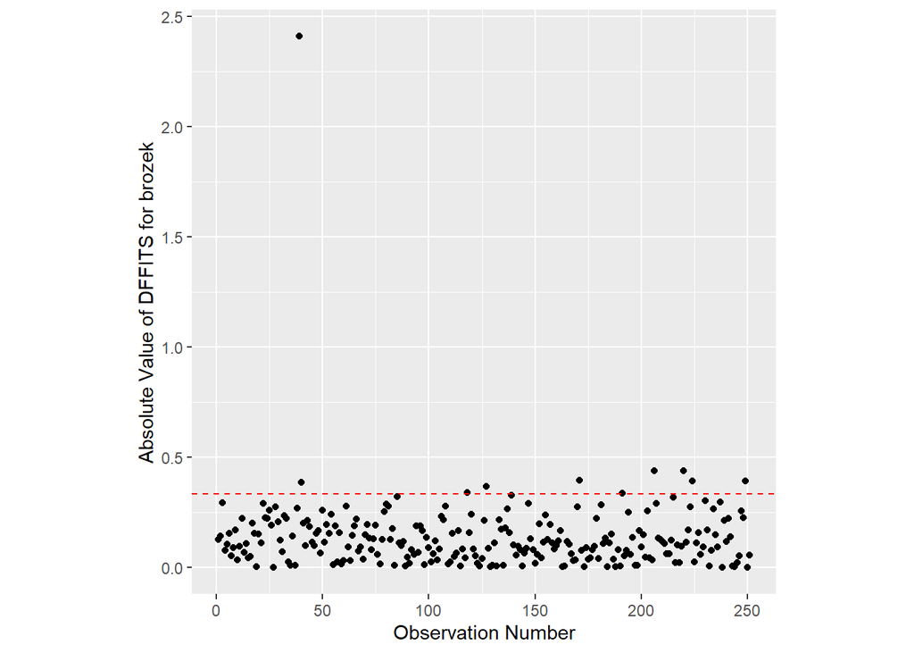

```r
# DFFITS
bodyfat$dffits <- dffits(bodyfat_lm)

# plot the DFFITS against the observation number
ggplot(data = bodyfat) +
  geom_point(mapping = aes(x = as.numeric(rownames(bodyfat)),
                           y = abs(dffits))) +
  ylab("Absolute Value of DFFITS for brozek") +
  xlab("Observation Number") +
  # for n > 30
  geom_hline(mapping = aes(yintercept = 2 * sqrt(length(bodyfat_lm$coefficients) /
                                                   length(dffits))),
             color = "red",
             linetype = "dashed")+
  theme(aspect.ratio = 1)
```

#### 19. (R) Additional predictor variables are not required (no diagnostic tools - just think about the variables you have and if there are other variables you think would help predict the response)

I can’t think of any additional variables that are required. There’s more things one could measure like wrist circumference or calf circumference, but those don’t really make sense on why those could read body fat percentage.

#### 20. No multicollinearity (for this assumption, compute the variance inflation factors (VIFs) and compare the VIFs to your comments in questions 5. Do the variance inflation factors match your assumptions from questions 5? Is this assumption met?

```r
# your code here
vif(bodyfat_lm)
```

```
##       age    weight    height      neck     chest     abdom
##  1.510958 19.128777  2.306983  3.545106  8.604128 10.684888
```

This assumptions is not met. Weight, abdom, and chest are way higher than 2. I think I was right about these variables in my reponse in question 5, they seem to be related to each other, especially weight.

### Note: your next homework assigment will use this same data set, and you will be asked to fix the assumptions that were broken.

#### 21. Briefly summarize what you learned, personally, from this analysis about the statistics, model fitting process, etc.

I find it really interesting how multicollinearity can mess with a model. I never thought about it before but I see that it can skew the data.

#### 22. Briefly summarize what you learned from this analysis *to a non-statistician*. Write a few sentences about (1) the purpose of this data set and analysis and (2) what you learned about this data set from your analysis. Write your response as if you were addressing a business manager (avoid using statistics jargon) and just provide the main take-aways.

The body fat data set shows what can determine a high or low body fat percentage (brozek). Weight and neck size have an negative relationship with body fat percentage, meaning that as weight or neck size increase, body fat percentage decreases, by very little. As abdominal circumference increases, body fat percentage will increase.